# CEF Socio-economic indicators

# Disturbance

### All data

|  | CENSUS_DIVISION_NAME | Total | Forestry | Logging | Wood.Manufacturing | Mining..Oil.and.Gas | Tourism. |
| --- | --- | --- | --- | --- | --- | --- | --- |
| 1 | British Columbia | 2433060 | 52,950 | 15,760 | 37,180 | 28,410 | 85,800 |
| 2 | East Kootenay | 31520 | 1,430 | 480 | 950 | 3,660 | 1,580 |
| 3 | Cranbrook | 12760 | 590 | 180 | 410 | 700 | 470 |
| 4 | Fernie | 8740 | 250 | 110 | 140 | 2,490 | 370 |
| 5 | Invermere | 5530 | 380 | 140 | 240 | 160 | 470 |
| 6 | Kimberley | 4460 | 250 | 40 | 210 | 300 | 270 |
| 7 | Central Kootenay | 27190 | 1,960 | 870 | 1,090 | 820 | 1,000 |
| 8 | Castlegar-Arrow Lakes | 7610 | 780 | 200 | 580 | 410 | 230 |
| 9 | Creston | 5360 | 470 | 180 | 290 | 210 | 160 |
| 10 | Nelson | 9410 | 350 | 250 | 100 | 130 | 400 |

[output cut: 123 more lines]

# Additional Info

## Local Area Economic Profile Information

### Preliminary model

These are preliminary results of the first phase of the Local Area Economic Profiles model. This model is being reconstructed based on previous reports published by BC Stats. Phase two will be published by March 31, 2024.

### 2020 reference year

The model uses data from the 2016 and 2021 Censuses. The reference years are for 2015 and 2020, respectively, as those are deemed the most appropriate by Statistics Canada because of how people respond to the Census.

The 2020 reference year presents multiple problems that readers should be aware of. First, in a normal year most people’s employment status is not expected to change much. Between 2020 and 2021, however, many people lost jobs, worked reduced hours and lost income, and/or changed jobs due to impacts related to the COVID-19 pandemic.

Second, at the time of publication, the 2020 input-output tables had not been released by Statistics Canada, so this study uses the 2019 tables to represent the macroeconomic structure of B.C.’s economy.

Despite these known problems, BC Stats has decided to publish the 2020 results for readers’ interest. Some indicators should not be affected – for example, the Location Quotients and dominant basic income sources – while some will be impacted more.

Results for the 2015 reference year are considered more reliable, though both reference years are available in the detailed results workbook.

Additionally, we have decided not to publish statistics that use the “rest of province” geographical impact variable, available for the Income Dependence and Employment Impact Ratio indicators because the model calculates unreasonably high demand for many service sectors, and BC Stats needs to address how those excesses get reallocated by the model. BC Stats will work to address these issues in future updates of the model.

### First Nations

First Nations people are mixed in with the data for every local area and their results are not distinguishable separately. However, two local areas were chosen which correspond with the census subdivisions specific to nations: Haida Nation and Nisga’a.

### Not a model of economic development

The local area economic model has its foundation in Economic Base Theory. This theory assumes that a community’s exports and external sources of income are its “economic base” and are important because they pay for imports.

Readers should be cautioned that, while Economic Base Theory provides some useful descriptive statistics, it tells us little about how regions become more prosperous over time. Regions with a high proportion of jobs in export-oriented industries are sometimes the most post-industrial or low income places where people don’t want to live.

Both basic and non-basic activities are needed to make a community more than just a work camp, and there are other theories of economic growth that tell us it is primarily people – their education levels, network effects, quality of life and so on – that matter to the economic prosperity of a region.

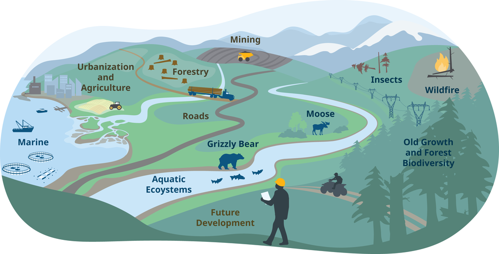

````r
---
title: "CEF Socio-economic indicators"
output:
  flexdashboard::flex_dashboard:
    source_code: embed
    css: custom.css
    favicon: favicon.ico
---

```{r setup, include=FALSE}
library(highcharter)
library(terra)
library(tidyterra)
library(sf)
library(DT)
library(tidyverse)
library(viridisLite)
library(forecast)
library(treemap)
library(arules)
library(geojsonsf)
library(geojsonio)
library(flexdashboard)
thm <-
  hc_theme(
    colors = c("#042f4b", "#005480", "#a4c1d8", "#85c495"),
    chart = list(
      backgroundColor = "transparent",
      style = list(fontFamily = "Source Sans Pro")
    ),
    xAxis = list(
      gridLineWidth = 1
    )
  )

```
Sidebar {.sidebar}
==============
::: sidebar-content
<!-- Logo --> <img src="slogo.png" alt="Logo" class="sidebar-logo"/>

<!-- Sidebar text -->

<p>This is a draft dashboard showing the key CEF socio-economic indicators used in the mock-up current condition report.</p>

<!-- Link to external resource -->

<p>In this section we can link to our website or the pdf of the report:</p>

[CEF Economic Report](https://www2.gov.bc.ca/gov/content/environment/natural-resource-stewardship/cumulative-effects-framework)

<p>The Local Area Economic Profile Report is a new edition of an economic model that was previous called the Local Area Economic Dependencies and was last published by BC Stats in 2009. Results shown here are preliminary and BC Stats is seeking feedback from users. To provide feedback please email BCStats@gov.bc.ca. This project creates a consistent economic model for 103 local areas in British Columbia. It combines detailed census data with the province's macroeconomic input-output model and is primarily intended to provide information on rural areas and to help estimate the impact of economic changes.</p>
:::

Welcome Page {data-orientation=columns}
=============
### Some demo text to explain the app and its context. This is super draft.
<div>
  <h2>Executive Summary</h2>
  <p>
    The distribution of economic activity plays a critical role in shaping the prosperity of regions, particularly in rural and resource-dependent communities. Economic resilience is influenced by the diversity of sectors, the stability of industries, and the broader economic landscape. When economies become overly reliant on a single sector, external shocks—such as shifts in commodity prices, policy changes such as tariffs, or environmental constraints—can have outsized impacts on local livelihoods.
  </p>
  <p>
    Sector diversification, sustainable resource management, and strategic economic planning help buffer communities against these risks, supporting stable employment, attracting investment, and fostering long-term economic stability. Though a community with a dominant industry may be better off than one with a number of smaller industries, a diversified economic base will provide more community stability in uncertain economic times.
  </p>
  <p>
    Additionally, the prosperity of a local community depends on much more than the economic performance of its basic industries. Culture, education level, income equality, investment levels, and environmental prosperity all contribute to local prosperity. Looking at select socio-economic indicators only provides an insight into some contributing factors of what drives and sustains local communities.
  </p>
  <p>
    Economies are inherently complex, shaped by local, national, and global factors that cannot always be fully captured through quantitative data alone. While indicators such as employment rates, income levels, and industry outputs provide useful insights, they do not always dictate the best course of action for economic development. Context is essential—understanding the broader economic landscape allows decision-makers to assess challenges, identify emerging opportunities, and make informed choices tailored to the region’s specific circumstances.
  </p>
  <p>
    This report compiles key economic data for the economic census region of BC, providing a structured synthesis of economic trends and conditions. It is not intended as a prescriptive economic development plan, nor does it outline specific policy recommendations. Instead, it serves as a foundational resource to help illuminate critical questions, risks, and opportunities facing communities in the region, equipping decision-makers with the necessary information to guide discussions and future strategies.
  </p>
</div>

<div>
  <h2>Introduction</h2>
  <p>
    The Province of British Columbia (the Province) has developed the Cumulative Effects Framework (CEF) to measure the impacts of natural resource activities on values that are important to the people of British Columbia (B.C.). The CEF provides a structured approach to evaluating how multiple factors influence regional conditions, aiming to support informed decision-making and minimize unintended consequences. A core component of this framework is the assessment of current conditions, which provides a baseline understanding of key values.
  </p>
  <p>
    This report examines the socio-economic conditions, synthesizing key indicators to provide an overview of the region’s economic landscape. Data and analysis presented here help frame the broader context in which communities operate. By compiling and interpreting relevant economic information, this report contributes to a clearer understanding of the factors shaping the region’s economy. The indicators presented in this report include:
  </p>
  <ul>
    <li>Employment rates by sectors</li>
    <li>Revenue brought in by each sector</li>
    <li>Economic resilience indicator</li>
    <li>Changes to employment over time</li>
    <li>Upcoming major projects</li>
    <li>The footprint of selected basic industries across the landscape (Forestry, Oil and Gas, Mining, and Agriculture)</li>
  </ul>
  <img src="cef_general_corelandscape.png" alt="CEF core landscape" style="width: 100%; height: auto; display: block; margin: 20px 0;">

</div>

Employment and Income {data-orientation=columns}
=============
````

````r
Column {data-width=600}
-----------------------------------------------------------------------

### BC Sector

```{r}
bcdata_2015 <- as.data.frame(read_csv("jobs_BC_2015.csv"))
bcdata_2020 <- as.data.frame(read_csv("jobs_BC_2020.csv"))

# Create the interactive bar chart
highchart() %>%
  hc_chart(type = "column") %>%
  hc_title(text = "BC Employment") %>%
  hc_xAxis(categories = bcdata_2015$Sector) %>%
  hc_yAxis(title = list(text = "Jobs")) %>%
  hc_add_series(name = "2015", data = bcdata_2015$Jobs, visible = TRUE) %>%
  hc_add_series(name = "2020", data = bcdata_2020$Jobs) %>%
  hc_tooltip(valueSuffix = " jobs") %>%
  hc_exporting(enabled = TRUE) %>%
  hc_chart(type = "column", zoomType = "x")%>%
  hc_chart(events = list(
    load = JS("
      function() {
        var chart = this;
        chart.update({
          navigation: {
            menuItemStyle: {
              backgroundColor: '#042f4b',
              borderColor: '#ccc'
            },
            buttonStyle: {
              backgroundColor: '#005480',
              borderColor: '#2f7ed8'
            },
            menuItems: [
              {
                text: 'Show 2015 Data',
                onclick: function() {
                  chart.series[0].setVisible(true);
                  chart.series[1].setVisible(true);
                  chart.series[2].setVisible(true);
                  chart.series[3].setVisible(false);
                  chart.series[4].setVisible(false);
                  chart.series[5].setVisible(false);
                }
              },
              {
                text: 'Show 2020 Data',
                onclick: function() {
                  chart.series[0].setVisible(false);
                  chart.series[1].setVisible(false);
                  chart.series[2].setVisible(false);
                  chart.series[3].setVisible(true);
                  chart.series[4].setVisible(true);
                  chart.series[5].setVisible(true);
                }
              }
            ]
          }
        });
      }
    ")
  ))

```
### trend

```{r}
employ_trend <- as.data.frame(read_csv("Employment_NRS_10_yrs.csv"))

hchart(
  employ_trend,
  "spline",
  hcaes(x = Year, y = People)
) %>%
  hc_title(text = "Employment Trend Over 10 Years") %>%
  hc_yAxis(
    title = list(text = "Number of People Employed"),
    min = 0
  ) %>%
  hc_xAxis(
    title = list(text = "Year")
  ) %>%
  hc_tooltip(
    pointFormat = "<b>{point.y:,.0f}</b> people employed in <b>{point.x}</b>"
  )

```

Map of sectors{data-width=600}
-------------------

### Jobs Per Region

```{r}

my_dsdata_2020 <- read.csv("cleaned_descriptive_stats.csv")

my_dsdata_2020 <- as.data.frame(my_dsdata_2020)

geojson2020eda <- geojsonio::geojson_read("EDA_geom.geojson")


n <- 4

colstopsd <- data.frame(
  q = 0:n/n,
  c = substring(viridis(n + 1), 0, 7)) %>%
  list_parse2()

highchart() %>%
  hc_add_series_map(geojson2020eda, my_dsdata_2020,
                    name = "Overview Stats",
                     joinBy = c("EDA", "EDA"),
                    value = "Population",
                    dataLabels = list(enabled = TRUE,
                                      format = '{point.properties.EDA}')) %>%
  hc_colorAxis(stops = colstopsd) %>%
  hc_legend(valueDecimals = 0) %>%
  hc_mapNavigation(enabled = TRUE) %>%
  hc_tooltip(
  useHTML = TRUE,
  headerFormat = '<div style="font-weight:bold; font-size:14px;">Overview Stats - {point.properties["EDA"]}</div>',
  pointFormat = paste0(
    '<table style="margin-top:4px;">',
    '<tr><td style="padding-right: 10px">Population:</td><td>{point.value}</td></tr>',
    '<tr><td>Total Jobs:</td><td>{point.Total_Jobs}</td></tr>',
    '<tr><td>Main Sector:</td><td>{point.DPS}</td></tr>',
    '</table>'
  )
)
```
Sector Revenue {data-orientation=columns}
=======================

## Sector Jobs {.tabset}

### Cariboo

```{r}
data_2015 <- as.data.frame(read_csv("Cariboo_2015.csv"))
data_2020 <- as.data.frame(read_csv("Cariboo_2020.csv"))

# Create the interactive bar chart
highchart() %>%
  hc_chart(type = "column") %>%
  hc_title(text = "Cariboo NRS sector emplyment") %>%
  hc_xAxis(categories = data_2015$Sector) %>%
  hc_yAxis(title = list(text = "Jobs")) %>%
  hc_add_series(name = "2015", data = data_2015$Jobs, visible = TRUE) %>%
  hc_add_series(name = "2020", data = data_2020$Jobs) %>%
  hc_tooltip(valueSuffix = " jobs") %>%
  hc_exporting(enabled = TRUE) %>%
  hc_chart(events = list(
    load = JS("
      function() {
        var chart = this;
        chart.update({
          navigation: {
            menuItemStyle: {
              backgroundColor: '#f7f7f7',
              borderColor: '#ccc'
            },
            buttonStyle: {
              backgroundColor: '#2f7ed8',
              borderColor: '#2f7ed8'
            },
            menuItems: [
              {
                text: 'Show 2015 Data',
                onclick: function() {
                  chart.series[0].setVisible(true);
                  chart.series[1].setVisible(true);
                  chart.series[2].setVisible(true);
                  chart.series[3].setVisible(false);
                  chart.series[4].setVisible(false);
                  chart.series[5].setVisible(false);
                }
              },
              {
                text: 'Show 2020 Data',
                onclick: function() {
                  chart.series[0].setVisible(false);
                  chart.series[1].setVisible(false);
                  chart.series[2].setVisible(false);
                  chart.series[3].setVisible(true);
                  chart.series[4].setVisible(true);
                  chart.series[5].setVisible(true);
                }
              }
            ]
          }
        });
      }
    ")
  ))

```

### Peace River

```{r}
Peacedata_2015 <- as.data.frame(read_csv("Peace_2015.csv"))
Peacedata_2020 <- as.data.frame(read_csv("Peace_2020.csv"))

# Create the interactive bar chart
highchart() %>%
  hc_chart(type = "column") %>%
  hc_title(text = "Interactive Bar Chart for 2015 and 2020 Data") %>%
  hc_xAxis(categories = Peacedata_2015$Sector) %>%
  hc_yAxis(title = list(text = "Jobs")) %>%
  hc_add_series(name = "Peace River (2015)", data = Peacedata_2015$Jobs, visible = TRUE) %>%
  hc_add_series(name = "Peace River (2020)", data = Peacedata_2020$Jobs) %>%
  hc_tooltip(valueSuffix = " jobs") %>%
  hc_exporting(enabled = TRUE) %>%
  hc_chart(events = list(
    load = JS("
      function() {
        var chart = this;
        chart.update({
          navigation: {
            menuItemStyle: {
              backgroundColor: '#f7f7f7',
              borderColor: '#ccc'
            },
            buttonStyle: {
              backgroundColor: '#2f7ed8',
              borderColor: '#2f7ed8'
            },
            menuItems: [
              {
                text: 'Show 2015 Data',
                onclick: function() {
                  chart.series[0].setVisible(true);
                  chart.series[1].setVisible(true);
                  chart.series[2].setVisible(true);
                  chart.series[3].setVisible(false);
                  chart.series[4].setVisible(false);
                  chart.series[5].setVisible(false);
                }
              },
              {
                text: 'Show 2020 Data',
                onclick: function() {
                  chart.series[0].setVisible(false);
                  chart.series[1].setVisible(false);
                  chart.series[2].setVisible(false);
                  chart.series[3].setVisible(true);
                  chart.series[4].setVisible(true);
                  chart.series[5].setVisible(true);
                }
              }
            ]
          }
        });
      }
    ")
  ))
````

````r
```
### Bulkley-Nechacko

```{r}
Bulkleydata_2015 <- as.data.frame(read_csv("Bulkley_2015.csv"))
Bulkleydata_2020 <- as.data.frame(read_csv("Bulkley_2020.csv"))

# Create the interactive bar chart
highchart() %>%
  hc_chart(type = "column") %>%
  hc_title(text = "Interactive Bar Chart for 2015 and 2020 Data") %>%
  hc_xAxis(categories = Bulkleydata_2015$Sector) %>%
  hc_yAxis(title = list(text = "Jobs")) %>%
  hc_add_series(name = "Bulkley-Nechako (2015)", data = Bulkleydata_2015$Jobs, visible = TRUE) %>%
  hc_add_series(name = "Bulkley-Nechako (2020)", data = Bulkleydata_2020$Jobs) %>%
  hc_tooltip(valueSuffix = " jobs") %>%
  hc_exporting(enabled = TRUE) %>%
  hc_chart(events = list(
    load = JS("
      function() {
        var chart = this;
        chart.update({
          navigation: {
            menuItemStyle: {
              backgroundColor: '#f7f7f7',
              borderColor: '#ccc'
            },
            buttonStyle: {
              backgroundColor: '#2f7ed8',
              borderColor: '#2f7ed8'
            },
            menuItems: [
              {
                text: 'Show 2015 Data',
                onclick: function() {
                  chart.series[0].setVisible(true);
                  chart.series[1].setVisible(true);
                  chart.series[2].setVisible(true);
                  chart.series[3].setVisible(false);
                  chart.series[4].setVisible(false);
                  chart.series[5].setVisible(false);
                }
              },
              {
                text: 'Show 2020 Data',
                onclick: function() {
                  chart.series[0].setVisible(false);
                  chart.series[1].setVisible(false);
                  chart.series[2].setVisible(false);
                  chart.series[3].setVisible(true);
                  chart.series[4].setVisible(true);
                  chart.series[5].setVisible(true);
                }
              }
            ]
          }
        });
      }
    ")
  ))

```

Ecosystem Services {data-orientation=columns}
=========

Map of sectors{.tabset}
-------------------

### Example One

```{r}

my_dsdata_2020 <- read.csv("cleaned_descriptive_stats.csv")

my_dsdata_2020 <- as.data.frame(my_dsdata_2020)

geojson2020eda <- geojsonio::geojson_read("EDA_geom.geojson")


n <- 4

colstopsd <- data.frame(
  q = 0:n/n,
  c = substring(viridis(n + 1), 0, 7)) %>%
  list_parse2()

highchart() %>%
  hc_add_series_map(geojson2020eda, my_dsdata_2020,
                    name = "Overview Stats",
                     joinBy = c("EDA", "EDA"),
                    value = "Population",
                    dataLabels = list(enabled = TRUE,
                                      format = '{point.properties.EDA}')) %>%
  hc_colorAxis(stops = colstopsd) %>%
  hc_legend(valueDecimals = 0) %>%
  hc_mapNavigation(enabled = TRUE) %>%
  hc_tooltip(
  useHTML = TRUE,
  headerFormat = '<div style="font-weight:bold; font-size:14px;">Overview Stats - {point.properties["EDA"]}</div>',
  pointFormat = paste0(
    '<table style="margin-top:4px;">',
    '<tr><td style="padding-right: 10px">Population:</td><td>{point.value}</td></tr>',
    '<tr><td>Total Jobs:</td><td>{point.Total_Jobs}</td></tr>',
    '<tr><td>Main Sector:</td><td>{point.DPS}</td></tr>',
    '</table>'
  )
)
```

### Example Two

```{r}

my_dsdata_2020 <- read.csv("cleaned_descriptive_stats.csv")

my_dsdata_2020 <- as.data.frame(my_dsdata_2020)

geojson2020eda <- geojsonio::geojson_read("EDA_geom.geojson")


n <- 4

colstopsd <- data.frame(
  q = 0:n/n,
  c = substring(viridis(n + 1), 0, 7)) %>%
  list_parse2()

highchart() %>%
  hc_add_series_map(geojson2020eda, my_dsdata_2020,
                    name = "Overview Stats",
                     joinBy = c("EDA", "EDA"),
                    value = "Population",
                    dataLabels = list(enabled = TRUE,
                                      format = '{point.properties.EDA}')) %>%
  hc_colorAxis(stops = colstopsd) %>%
  hc_legend(valueDecimals = 0) %>%
  hc_mapNavigation(enabled = TRUE) %>%
  hc_tooltip(
  useHTML = TRUE,
  headerFormat = '<div style="font-weight:bold; font-size:14px;">Overview Stats - {point.properties["EDA"]}</div>',
  pointFormat = paste0(
    '<table style="margin-top:4px;">',
    '<tr><td style="padding-right: 10px">Population:</td><td>{point.value}</td></tr>',
    '<tr><td>Total Jobs:</td><td>{point.Total_Jobs}</td></tr>',
    '<tr><td>Main Sector:</td><td>{point.DPS}</td></tr>',
    '</table>'
  )
)
```

Map of sectors
-------------------

### Jobs Per Region

```{r}

my_dsdata_2020 <- read.csv("cleaned_descriptive_stats.csv")

my_dsdata_2020 <- as.data.frame(my_dsdata_2020)

geojson2020eda <- geojsonio::geojson_read("EDA_geom.geojson")


n <- 4

colstopsd <- data.frame(
  q = 0:n/n,
  c = substring(rainbow(n + 1), 0, 7)) %>%
  list_parse2()

highchart() %>%
  hc_add_series_map(geojson2020eda, my_dsdata_2020,
                    name = "Overview Stats",
                     joinBy = c("EDA", "EDA"),
                    value = "Population",
                    dataLabels = list(enabled = TRUE,
                                      format = '{point.properties.EDA}')) %>%
  hc_colorAxis(stops = colstopsd) %>%
  hc_legend(valueDecimals = 0) %>%
  hc_mapNavigation(enabled = TRUE) %>%
  hc_tooltip(
  useHTML = TRUE,
  headerFormat = '<div style="font-weight:bold; font-size:14px;">Overview Stats - {point.properties["EDA"]}</div>',
  pointFormat = paste0(
    '<table style="margin-top:4px;">',
    '<tr><td style="padding-right: 10px">Population:</td><td>{point.value}</td></tr>',
    '<tr><td>Total Jobs:</td><td>{point.Total_Jobs}</td></tr>',
    '<tr><td>Main Sector:</td><td>{point.DPS}</td></tr>',
    '</table>'
  )
)
```
Economic Diversity  {data-orientation=colums}
=========

Column {data-width="150"}
-----------------------------

### Text
<p> Though a community with one dominant industry may be better off than one with a number of smaller industries, a diversified economic base will provide more community stability in volatile economic times.  This is what the Diversity Index measures.
````

````r
It measures the standard deviation of the income dependence on each basic income source, compared to the standard deviation of a region which was 100% dependent on just one source.

The Diversity Index would be zero if the area were entirely dependent on one sector. At the other extreme, it would be 100 if a local area were equally dependent on each of the defined sectors. In practice it tends to be between 50 and 80 in BC.</p>

Column {.tabset}
----------------------------
### Location Quoteint
```{r}
lq <- as.data.frame(read_csv("lq.csv"))
names_lq <- names(lq)[3:33]
DT::datatable(lq,
               width = "100%",

              options = list(
  pageLength = 200,
    scrollX = TRUE
)) %>%
 formatStyle(
    names_lq,
    color = styleInterval(c(3, 3.8), c('white', 'blue', 'red')),
    backgroundColor = styleInterval(1, c('grey', 'orange'))
  )
```


### Local Supply Share
```{r}
lss <- as.data.frame(read_csv("lss.csv"))
DT::datatable(lss,
               width = "100%",

              options = list(
  pageLength = 200,
    scrollX = TRUE
))
```


Disturbance {data-orientation=columns}
==============

## Column {data-width="500"}

### All data

```{r}
my_data_2020 <- read.csv("raw_jobs_2020.csv")

my_data_2020 <- as.data.frame(my_data_2020)
DT::datatable(my_data_2020, options = list(
  pageLength = 25
))
```

Additional Info {data-orientation=scroll}
======================
### Text
<div>

  <h2>Local Area Economic Profile Information</h2>

  <h3>Preliminary model</h3>
  <p>
    These are preliminary results of the first phase of the Local Area Economic Profiles model. This model is being reconstructed based on previous reports published by BC Stats. Phase two will be published by March 31, 2024.
  </p>

  <h3>2020 reference year</h3>
  <p>
    The model uses data from the 2016 and 2021 Censuses. The reference years are for 2015 and 2020, respectively, as those are deemed the most appropriate by Statistics Canada because of how people respond to the Census.
  </p>
  <p>
    The 2020 reference year presents multiple problems that readers should be aware of. First, in a normal year most people’s employment status is not expected to change much. Between 2020 and 2021, however, many people lost jobs, worked reduced hours and lost income, and/or changed jobs due to impacts related to the COVID-19 pandemic.
  </p>
  <p>
    Second, at the time of publication, the 2020 input-output tables had not been released by Statistics Canada, so this study uses the 2019 tables to represent the macroeconomic structure of B.C.’s economy.
  </p>
  <p>
    Despite these known problems, BC Stats has decided to publish the 2020 results for readers’ interest. Some indicators should not be affected – for example, the Location Quotients and dominant basic income sources – while some will be impacted more.
  </p>
  <p>
    Results for the 2015 reference year are considered more reliable, though both reference years are available in the detailed results workbook.
  </p>
  <p>
    Additionally, we have decided not to publish statistics that use the “rest of province” geographical impact variable, available for the Income Dependence and Employment Impact Ratio indicators because the model calculates unreasonably high demand for many service sectors, and BC Stats needs to address how those excesses get reallocated by the model. BC Stats will work to address these issues in future updates of the model.
  </p>

  <h3>Social safety net is not modeled yet</h3>
  <p>
    Employment Impact Ratios (EIR) in this report are presented as if there were no social safety net. In reality, workers who are fired or new workers who are hired should not be assumed to have zero income; the income would be replaced by the social safety net such as unemployment insurance. See below. Impact ratios modeling the social safety net will be included in phase two.
  </p>

  <h3>Reference years</h3>
  <p>
    Reference years used in this report are for one year before when the Canadian Census was taken. See the discussion of the Census as a data source above for the reason why.
  </p>

  <h3>First Nations</h3>
  <p>
    First Nations people are mixed in with the data for every local area and their results are not distinguishable separately. However, two local areas were chosen which correspond with the census subdivisions specific to nations: Haida Nation and Nisga'a.
  </p>
  <p>
    Results were calculated for these local areas but BC Stats has chosen to omit them while we seek permission of the nations to publish them. In the case of Haida Nation, that local area represents the geographies and residents of Skidegaat and Old Masset only, as presented in census data, while the Haida Gwai local area represents the rest of Haida Gwai. See the blue EDA Boundaries sheet for more information.
  </p>

  <h3>Not a model of economic development</h3>
  <p>
    The local area economic model has its foundation in Economic Base Theory. This theory assumes that a community’s exports and external sources of income are its "economic base" and are important because they pay for imports.
  </p>
  <p>
    Readers should be cautioned that, while Economic Base Theory provides some useful descriptive statistics, it tells us little about how regions become more prosperous over time. Regions with a high proportion of jobs in export-oriented industries are sometimes the most post-industrial or low income places where people don’t want to live.
  </p>
  <p>
    Both basic and non-basic activities are needed to make a community more than just a work camp, and there are other theories of economic growth that tell us it is primarily people – their education levels, network effects, quality of life and so on – that matter to the economic prosperity of a region.
  </p>
  <img src="cef_general_corelandscape.png" alt="CEF core landscape" style="width: 100%; height: auto; display: block; margin: 20px 0;">

</div>
````